# ClarkNet Server Log Analysis and Recommendations

[figure not shown]

# 2. Exploratory Data Analysis and Visualizations

Here I discuss

- Most frequent requests
- Most active hosts
- Requests returned with "bad" status code
- Most active posts including suspicious activity

First I read the DataTable from the saved parquet file, check columns and Schema

```python
# read DataFrame from json file
sqlContext = SQLContext(sc)
accessLogs_DF = sqlContext.read.load("accessLogs.parquet", format="parquet").cache()
#df = sqlContext.read.json("accessLogs.json").cache()
print "Columns:",  accessLogs_DF.columns
print "Statistic of numeric columns:"
accessLogs_DF.describe().show()
print "Schema of the DataTable"
accessLogs_DF.printSchema()
```

```
Columns: ['content_size', 'date_time', 'host', 'method', 'request', 'response_code']
Statistic of numeric columns:
+-------+-----------------+------------------+
|summary|     content_size|     response_code|
+-------+-----------------+------------------+
|  count|          1673716|           1673716|
|   mean|  8684.2054601856|213.97359767128953|
| stddev|36530.22411160573| 41.84922941436038|
|    min|                0|               200|
|    max|          5597650|               500|
+-------+-----------------+------------------+

Schema of the DataTable
root
 |-- content_size: long (nullable = true)
 |-- date_time: timestamp (nullable = true)
 |-- host: string (nullable = true)
 |-- method: string (nullable = true)
 |-- request: string (nullable = true)
 |-- response_code: long (nullable = true)
```

Let us count distinct hosts and distinct requests.

```python
N_total = accessLogs_DF.count()
N_host = accessLogs_DF.select("host").distinct().count()
N_request = accessLogs_DF.select("request").distinct().count()
print N_host, "distinct hosts issued", N_request, "distinct requests with", N_total, "records altogether"
```

```
94770 distinct hosts issued 36759 distinct requests with 1673716 records altogether
```

The same with a different syntax

```python
import pyspark.sql.functions as func
N_host = accessLogs_DF.agg(func.countDistinct(accessLogs_DF.host)).collect()[0][0]
N_request = accessLogs_DF.agg(func.countDistinct(accessLogs_DF.request)).collect()[0][0]
print N_host, "distinct hosts issued", N_request, "distinct requests with", N_total, "records altogether"
```

```
94770 distinct hosts issued 36759 distinct requests with 1673716 records altogether
```

The same with SQL query

```python
accessLogs_DF.registerTempTable("ta")
temp = sqlContext.sql("SELECT COUNT(*) as total, COUNT(DISTINCT(host)) as N_hosts, COUNT(DISTINCT(request)) as N_requests FROM ta")
N_total, N_host, N_request = temp.collect()[0]
print N_host, "distinct hosts issued", N_request, "distinct requests with", N_total, "records altogether"
```

```
94770 distinct hosts issued 36759 distinct requests with 1673716 records altogether
```

### Most frequent requests

To estimate the most popular pages at our web site, let us find out which requests were issued most frequently. Here we are only interested in records with "GET" method, which in our case are nearly all of records.

```python
GETlogs_DF = accessLogs_DF.filter(accessLogs_DF.method=="GET").drop("method").cache()
print "There are", GETlogs_DF.count(), "records with GET method"
```

```
There are 1669489 records with GET method
```

Let us calculate the number of times each request was issued and sort in descending order

```python
request_DF = GETlogs_DF.groupBy("request").count().sort("count", ascending=False).cache()
request_DF.show(n=10, truncate=False)
```

```
+---------------------------------+-----+
|request                          |count|
+---------------------------------+-----+
|/pub/atomicbk/catalog/logo2.gif  |20731|
|/pub/atomicbk/catalog/home.gif   |19827|
|/pub/atomicbk/catalog/catalog.gif|19679|
|/pub/atomicbk/catalog/new.gif    |19330|
|/pub/atomicbk/catalog/orders.gif |19143|
|/pub/journalism/awesome.html     |17568|
|/pub/job/vendela.jpg             |16359|
|/pub/atomicbk/catalog/mini.gif   |15276|
|/pub/job/vk/vendela.html         |14062|
|/pub/job/vk/bam.gif              |12465|
+---------------------------------+-----+
only showing top 10 rows
```

The same can be done with SQL query. By comparing the counts for the top-10 requests (ot do it yourself with any number of requests) one can check that the results are the same

```python
#accessLogs_DF.registerTempTable("ta")
temp = sqlContext.sql("SELECT request, COUNT(*) as N_request FROM ta WHERE method='GET' GROUP BY request ORDER BY N_request DESC")
temp.show(n=10, truncate=False)
```

```
+---------------------------------+---------+
|request                          |N_request|
+---------------------------------+---------+
|/pub/atomicbk/catalog/logo2.gif  |20731    |
|/pub/atomicbk/catalog/home.gif   |19827    |
|/pub/atomicbk/catalog/catalog.gif|19679    |
|/pub/atomicbk/catalog/new.gif    |19330    |
|/pub/atomicbk/catalog/orders.gif |19143    |
|/pub/journalism/awesome.html     |17568    |
|/pub/job/vendela.jpg             |16359    |
|/pub/atomicbk/catalog/mini.gif   |15276    |
|/pub/job/vk/vendela.html         |14062    |
|/pub/job/vk/bam.gif              |12465    |
+---------------------------------+---------+
only showing top 10 rows
```

#### Top-10 by unique users

The table above shows how many times each request was issued. If one and the same host issued the same request multiple times, each time is counted. For business applications one is more interested in counting requests by *unique* hosts. This may lead to a different ranking

```python
request_by_uniqueHost_DF = (GETlogs_DF
                            .groupBy("request")
                            .agg(func.countDistinct(GETlogs_DF.host))
                            .sort("count(host)", ascending=False))
request_by_uniqueHost_DF.show(n=10, truncate=False)
```

```
+----------------------------------+-----------+
|request                           |count(host)|
+----------------------------------+-----------+
|/pub/atomicbk/catalog/logo2.gif   |15496      |
|/pub/atomicbk/catalog/home.gif    |15402      |
|/pub/atomicbk/catalog/catalog.gif |15323      |
|/pub/atomicbk/catalog/new.gif     |15043      |
|/pub/atomicbk/catalog/orders.gif  |14901      |
|/pub/atomicbk/catalog/mini.gif    |12458      |
|/pub/job/vendela.jpg              |11281      |
|/pub/job/vk/vendela.html          |10331      |
|/pub/job/vk/bam.gif               |9260       |
|/pub/atomicbk/catalog/sleazbk.html|9057       |
+----------------------------------+-----------+
only showing top 10 rows
```

```python
#python list of top-10 requests
request_top10 = set(row[0] for row in request_DF.take(10))
#pprint(request_top10)
# make it broadcast variable
request_top10_bc = sc.broadcast(request_top10)
```

We found top-10 requests. But with what codes were they returned? Can it be that the request was issued again and again only because it was often not found. Thus we are interested to count various status codes for each request.

```python
request_code = (GETlogs_DF[GETlogs_DF.request.isin(request_top10_bc.value)] # select records ion top-10
                   .groupBy("request", "response_code").count() # create pivot table
                   .toPandas()) # create Pandas data frame for visualization
request_code.head()
```

|  | request | response_code | count |
| --- | --- | --- | --- |
| 0 | /pub/atomicbk/catalog/orders.gif | 304 | 1959 |
| 1 | /pub/job/vk/vendela.html | 200 | 13031 |
| 2 | /pub/job/vk/vendela.html | 404 | 4 |
| 3 | /pub/journalism/awesome.html | 304 | 2277 |
| 4 | /pub/atomicbk/catalog/catalog.gif | 200 | 17634 |

It is always helpful to visualize the results. Counts of top-10 request for various response codes clearly show that the absolute majority of these requests were returned with "OK" (200) status code. Sometimes the response code was was "not Modified" (304), which means that the host already had a valid representation of the request and no data transfer was required. The number of "not Found" responses is very small and not visible at the plot as it is (with linear scale horizontal axis).

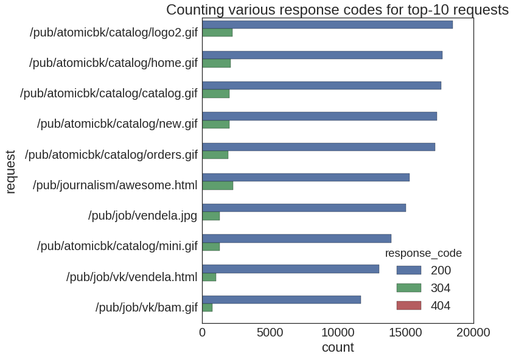

```python
import matplotlib.pyplot as plt
%matplotlib inline
import seaborn as sns
request_code.sort_values('count', ascending=False, inplace=True)
#sns.set_style("white")
sns.set(font_scale=2, style="white")
plt.figure(figsize=(8, 9))
plt.title("Counting various response codes for top-10 requests")
ax = sns.barplot(x='count', y='request', data=request_code, hue="response_code", alpha=1.0)
ax.set_xlabel("count")
```

Another interesting question is: how many of our web-pages are "popular" and how many are not. First I count how many times each request was issued (the more times, the more popular this request is). Then I count the number of requests with a given "popularity". The resulting histogram is shown below

```python
histogram_request = request_DF.rdd.values().histogram([2**i for i in range(16)])
print "Histogram is calculated in distibuted way \n", "\n".join([str(i) for i in histogram_request])
```

```
Histogram is calculated in distibuted way
[1, 2, 4, 8, 16, 32, 64, 128, 256, 512, 1024, 2048, 4096, 8192, 16384, 32768]
[16993, 5795, 3699, 3126, 2370, 1878, 1081, 721, 448, 200, 112, 97, 30, 19, 6]
```

```python
from collections import OrderedDict
from bokeh.io import output_notebook
from bokeh.plotting import figure, show, output_file
from bokeh.models import HoverTool
from bokeh.models.sources import ColumnDataSource

request = ColumnDataSource({'left': histogram_request[0][0:-1],
                                       'right': histogram_request[0][1:],
                                       'top': histogram_request[1],
                                       'bottom': [0]*len(histogram_request[1])})
p_request = figure(plot_width=800, plot_height=400,
           tools="save, hover",
           title="Counting requests issued a specific number of times",
           x_axis_type="log",
           y_axis_type="log",
           x_range=[1, 2**15],
           y_range=[4, 2**15],
           x_axis_label='number of times a particular request was issued',
           y_axis_label='count of requests'
          )

output_notebook()

hover_p_request = p_request.select(dict(type=HoverTool))
hover_p_request.tooltips = OrderedDict([('from ... to ... times', '(@left, @right)'), ('counts', '@top')])

p_request.quad(left='left', right='right', top='top', bottom='bottom', source=request,
       fill_color='green', fill_alpha=0.3, line_color='black')

show(p_request)
```

Loading BokehJS ...

`<Bokeh Notebook handle for In[13]>`

The rightmost column shows that the 6 most popular requests were issued more than 16382 times but less than 32768 times.

### Most active hosts

To estimate the most frequent users of our web site, let us find out which host issued the most number of requests. Again only records with "GET" method are of interest. Similarly to the top-10 requests, I make a list of top-10 hosts

```python
host_DF = GETlogs_DF.groupBy("host").count().sort("count", ascending=False).cache()
host_DF.show(n=10, truncate=False)
# python list of top-10
host_top10 = set(row[0] for row in host_DF.take(10))
#pprint(host_top10)
# make it broadcast variable
host_top10_bc = sc.broadcast(host_top10)
```

```
+----------------------+-----+
|host                  |count|
+----------------------+-----+
|piweba5y.prodigy.com  |7219 |
|clark.net             |5178 |
|www-e5.proxy.aol.com  |5122 |
|www-e6.proxy.aol.com  |4945 |
|www-e7.proxy.aol.com  |4903 |
|mpngate1.ny.us.ibm.net|4885 |
|www-e9.proxy.aol.com  |4716 |
|www-e3.proxy.aol.com  |4526 |
|www-e8.proxy.aol.com  |4492 |
|www-e4.proxy.aol.com  |4466 |
+----------------------+-----+
only showing top 10 rows
```

Let us check the response codes

```python
host_code = (GETlogs_DF[GETlogs_DF.host.isin(host_top10_bc.value)] # select records in top-10
                   .groupBy("host", "response_code").count() # create pivot table
                   .toPandas()) # create Pandas data frame for visualization
host_code.head()
```

|  | host | response_code | count |
| --- | --- | --- | --- |
| 0 | www-e4.proxy.aol.com | 200 | 3266 |
| 1 | www-e4.proxy.aol.com | 404 | 37 |
| 2 | www-e4.proxy.aol.com | 204 | 1 |
| 3 | clark.net | 500 | 2 |
| 4 | clark.net | 302 | 161 |

Visualization is always helpful

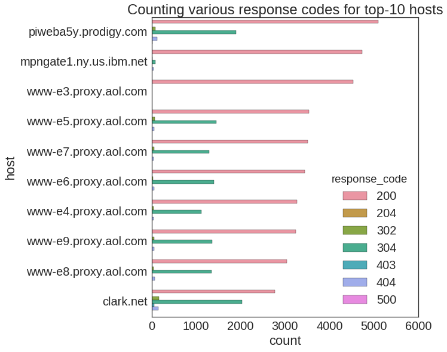

```python
host_code.sort_values('count', ascending=False, inplace=True)
plt.figure(figsize=(8, 9))
plt.title("Counting various response codes for top-10 hosts")
ax = sns.barplot(x='count', y='host', data=host_code, hue="response_code", alpha=1.0)
ax.set_xlabel("count")
```

One is happy to know that the most requests resulted in "OK" (200) response code and we saved some traffic by returning a "not Modified" (304) response code. This code means that the host already had a valid representation of the request and no data transfer was required.

Besides investigating top-10 hosts, it is interesting to know how often hosts visited our web-pages. Therefore we make a histogram how many hosts issued a specific number of requests

```python
histogram_host = host_DF.rdd.values().histogram([2**i for i in range(14)])
print "Histogram is calculated in distibuted way \n", "\n".join([str(i) for i in histogram_host])
```

```
Histogram is calculated in distibuted way
[1, 2, 4, 8, 16, 32, 64, 128, 256, 512, 1024, 2048, 4096, 8192]
[15683, 14336, 18683, 19460, 14428, 8490, 2650, 534, 196, 70, 28, 26, 13]
```

```python
host = ColumnDataSource({'left': histogram_host[0][0:-1],
                                       'right': histogram_host[0][1:],
                                       'top': histogram_host[1],
                                       'bottom': [0]*len(histogram_host[1])})
p_host = figure(plot_width=800, plot_height=400,
           tools="save, hover",
           title="Counting hosts issued each specific number of requests",
           x_axis_type="log",
           y_axis_type="log",
           x_range=[1, 2**14],
           y_range=[8, 2**15],
           x_axis_label='number of requests issued by a host',
           y_axis_label='counts of hosts'
          )

output_notebook()

hover_p_host = p_host.select(dict(type=HoverTool))
hover_p_host.tooltips = OrderedDict([('from ... to ... times', '(@left, @right)'), ('counts', '@top')])

p_host.quad(left='left', right='right', top='top', bottom='bottom', source=host,
       fill_color='blue', fill_alpha=0.2, line_color='black')

show(p_host)
```

Loading BokehJS ...

`<Bokeh Notebook handle for In[18]>`

The rightmost histogram column shows that the 13 most active hosts issued more than 4096 but less than 8192 requests.

### Requests returned with "bad" status code

To track the outdated or broken links on the web site we are interested to find requests that for the majority of times were returned with status code "Forbidden"(403), "not Found" (404) or "Internal Server Error"(505). Let us have a quick look at what we are searching for

```python
request_code_DF = GETlogs_DF.groupBy("request", "response_code").count()
request_code_DF.sort(["response_code", "count"], ascending=False).show(15)
```

```
+--------------------+-------------+-----+
|             request|response_code|count|
+--------------------+-------------+-----+
|/pub/jeffd/cgi-bi...|          500|  440|
|/pub/jeffd/cgi-bi...|          500|  313|
|/pub/jeffd/cgi-bi...|          500|  141|
|/pub/alweiner/cgi...|          500|   23|
|/pub/iz/cgi-bin/c...|          500|   19|
|/theme/cgi-bin/si...|          500|   18|
| /pub/jeffd/cgi-bin/|          500|   15|
|/pub/jeffd/cgi-bi...|          500|   14|
|/pub/alweiner/cgi...|          500|   13|
|/pub/jeffd/cgi-bi...|          500|   12|
|/web1one/cgi-bin/...|          500|   11|
|/pub/cybersoft/cg...|          500|    9|
|/pub/alweiner/cgi...|          500|    8|
|/theme/cgi-bin/se...|          500|    8|
|/home/cgi-bin/cou...|          500|    7|
+--------------------+-------------+-----+
only showing top 15 rows
```

One immediately see some of requests with a lot of "Internal Server Error" response codes. Now it is time to investigate those systematically.

This is what I am going to do for each request step by step.

- mark requests with codes 403, 404 or 505 as "bad" via binary variable
- for each request count "bad" and "total" response_codes
- divide "bad" counts by the "total" ones to get the percent of "bad"

The results are sorted by percentage of "bad" and then by counts of "bad" in descending order

```python
percentage_bad_DF = (GETlogs_DF.select("request","response_code")
                               .withColumn("is_bad",
                                           func.when(GETlogs_DF.response_code.isin(403, 404, 505), 1).otherwise(0))
                               .groupBy("request")
                               .agg(func.sum("is_bad").alias("bad"), func.count("is_bad").alias("total"))
                               .withColumn("percent_bad", func.col("bad")/func.col("total"))
                               .sort("percent_bad", "total", ascending=False)
                               )
percentage_bad_DF.show(5)
```

```
+--------------------+----+-----+-----------+
|             request| bad|total|percent_bad|
+--------------------+----+-----+-----------+
|/pub/atomicbk/ima...|2653| 2653|        1.0|
|/pub/atomicbk/ima...|1698| 1698|        1.0|
|/pub/mjoneill/lin...|1540| 1540|        1.0|
|/pub/atomicbk/iam...|1463| 1463|        1.0|
|/pub/listserv/dia...|1438| 1438|        1.0|
+--------------------+----+-----+-----------+
only showing top 5 rows
```

Count requests that were always "bad"

```python
percentage_bad_DF.filter("percent_bad = 1.0").count()
```

```
4082
```

There are 4082 unique requests that were never delivered to hosts. Red flag.

### Most active POSTs

Let us switch from GET to POST method. Some hosts were trying to POST something on our web page.

```python
POSTlogs_DF = accessLogs_DF.filter(accessLogs_DF.method=="POST").cache()
print "There are", POSTlogs_DF.count(), "records with POST method"
```

```
There are 2538 records with POST method
```

With only 2538 records we can refrain from using distributed computations with Apache Spark and use pandas data frame.

```python
POSTlogs=POSTlogs_DF.drop("method").toPandas()
POSTlogs.head()
```

|  | content_size | date_time | host | request | response_code |
| --- | --- | --- | --- | --- | --- |
| 0 | 305 | 1995-09-06 18:34:58 | dittrich.oz.net | /devtools/cgi-bin/steve.pl | 500 |
| 1 | 649 | 1995-09-06 18:36:31 | 204.199.132.207 | /pub/theme/cgi-bin/signup.html | 200 |
| 2 | 305 | 1995-09-06 18:37:03 | dittrich.oz.net | /devtools/cgi-bin/steve.pl | 500 |
| 3 | 0 | 1995-09-06 18:37:14 | 204.199.132.207 | /pub/theme/cgi-bin/ign.html | 302 |
| 4 | 646 | 1995-09-06 18:37:42 | kovalevski.math.LaTech.edu | /pub/theme/cgi-bin/signup.html | 200 |

Are there any hosts that tried to post the same request multiple times? For the most acrive posting host I found 103 "/home/cgi-bin/search.pl" requests from the "ed-zarrella-home.vitro.com". This means posting Perl scripts 103 times. Isn't this suspicious?

```python
ff = POSTlogs.groupby(["host", "request"])
dd = ff.count().sort_values('content_size', ascending=False)
dd.head()
```

| host | request | content_size | date_time | response_code |
| --- | --- | --- | --- | --- |
| ed-zarrella-home.vitro.com | /home/cgi-bin/search.pl | 103 | 103 | 103 |
| homation.clark.net | /homation/cgi-bin/registration.cgi | 38 | 38 | 38 |
| waire-ppp.clark.net | /pub/cybersoft/cgi-bin/mortgage | 31 | 31 | 31 |
| dyna231.intr.net | /pub/nbp/cgi-bin/proc-add.pl | 28 | 28 | 28 |
| zarrella.vitro.com | /home/cgi-bin/search.pl | 27 | 27 | 27 |

```python
suspicious_host, suspicious_request = dd.index[0]
print "Suspicious host is", suspicious_host, " with request", suspicious_request
```

```
Suspicious host is ed-zarrella-home.vitro.com  with request /home/cgi-bin/search.pl
```

```python
suspicious = POSTlogs[(POSTlogs.host==suspicious_host) & (POSTlogs.request==suspicious_request)].copy(deep=True)
suspicious.head()#.drop(["host", "request"])
```

|  | content_size | date_time | host | request | response_code |
| --- | --- | --- | --- | --- | --- |
| 689 | 1035 | 1995-09-04 16:35:25 | ed-zarrella-home.vitro.com | /home/cgi-bin/search.pl | 200 |
| 960 | 6394 | 1995-09-09 09:40:16 | ed-zarrella-home.vitro.com | /home/cgi-bin/search.pl | 200 |
| 962 | 7550 | 1995-09-09 09:41:04 | ed-zarrella-home.vitro.com | /home/cgi-bin/search.pl | 200 |
| 963 | 2598 | 1995-09-09 09:42:04 | ed-zarrella-home.vitro.com | /home/cgi-bin/search.pl | 200 |
| 964 | 1101 | 1995-09-09 09:42:24 | ed-zarrella-home.vitro.com | /home/cgi-bin/search.pl | 200 |

```python
suspicious.set_index(['date_time'], inplace=True)
suspicious.sort_index(inplace=True)
suspicious['textDate'] = suspicious.index.format()
suspicious.head()
#suspicious['response_code'].unique() # 200, 500
#suspicious.dtypes
```

| date_time | content_size | host | request | response_code | textDate |
| --- | --- | --- | --- | --- | --- |
| 1995-09-04 16:35:25 | 1035 | ed-zarrella-home.vitro.com | /home/cgi-bin/search.pl | 200 | 1995-09-04 16:35:25 |
| 1995-09-08 21:57:23 | 6376 | ed-zarrella-home.vitro.com | /home/cgi-bin/search.pl | 200 | 1995-09-08 21:57:23 |
| 1995-09-08 21:59:29 | 7558 | ed-zarrella-home.vitro.com | /home/cgi-bin/search.pl | 200 | 1995-09-08 21:59:29 |
| 1995-09-08 22:05:30 | 7558 | ed-zarrella-home.vitro.com | /home/cgi-bin/search.pl | 200 | 1995-09-08 22:05:30 |
| 1995-09-08 22:21:41 | 305 | ed-zarrella-home.vitro.com | /home/cgi-bin/search.pl | 500 | 1995-09-08 22:21:41 |

```python
source = ColumnDataSource(suspicious)

colormap = {200: 'green', 500: 'red'}
colors = [colormap[x] for x in suspicious['response_code']]

p_suspi = figure(plot_width=1000, plot_height=400,
           #tools="pan,box_zoom,reset,resize,save,hover",
           tools="reset,box_zoom, save, hover",
           title="Size of suspicious 'search.pl' posts over time",
           x_axis_type="datetime",
           x_range=[suspicious.index[0], suspicious.index[-1]],
           y_range=[0, 8000],
           x_axis_label='date and time',
           y_axis_label='content size',
          )

output_notebook()
output_file("p_suspi.html")

hover_p_suspi = p_suspi.select(dict(type=HoverTool))
hover_p_suspi.tooltips = OrderedDict([('date', '@textDate'),('content_size', '@content_size')])

p_suspi.line(x='date_time', y='content_size', source=source, line_color='blue')
p_suspi.circle(x='date_time', y='content_size', source=source, color=colors, fill_alpha=0.2, size=10)

show(p_suspi)
```

Loading BokehJS ...

`<Bokeh Notebook handle for In[28]>`